# Visualization Exercises Part 2

This is the second of several exercise pages on visualization using [Matplotlib](http://matplotlib.org/index.html) that were prepared for use in the course ITSE 1302 at Austin Community College.

Matplotlib can be used to create a large variety of types (line plots, histograms, etc.) and features (legends for example) of plots as you will see if you visit the [thumbnail gallery](http://matplotlib.org/2.0.2/gallery.html). The code for many of the features can be carried forward from one type of plot to another so that if you know how to create the feature for one type of plot, you also know how to create the feature for many different types of plots.

Perhaps the simplest type of plot is the line plot, which we will use as the vehicle for the application of features. This exercise page will provide brief explanations and demonstrations of the application of a variety of features using line plots as the vehicle.

## Import required libraries

```python
import numpy as np
import matplotlib.pyplot as plt
import math
```

## Axes.plot

We will begin with a discussion of Axes.plot. We have been using this method since the beginning but have yet to discuss it in detail.

As shown in the following plot, this method requires, as a minimum, a single list or arry containing the data values to be plotted. If only one list is provided, the horizontal scale defaults to the index values of the list, which is 0 through 6 in this case.

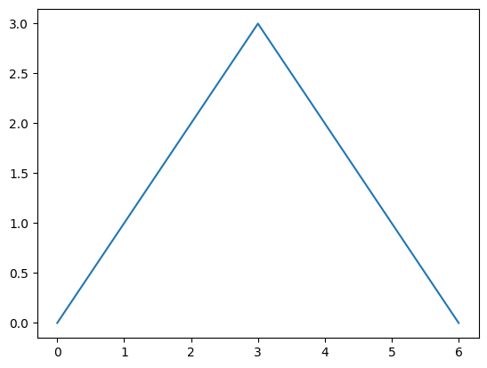

```python
fig,(ax0) = plt.subplots(1,1)

ax0.plot([0,1,2,3,2,1,0])
plt.savefig("VisualizationPart02.zzz.png")
plt.show()
```

## **Description of the image shown above, VisualizationPart02.01.png**

### Type of Image

A single line plot showing a triangular waveform formed by straight line segments. The plot begins at the origin, rises linearly to a peak at the midpoint, and then descends linearly back to zero.

### Overall Summary

The image illustrates the behavior of Axes.plot when given only one list of data values. Because only a single list is supplied, the x‑axis defaults to the index positions of the list elements, producing a simple piecewise linear plot.

### Detailed Description

The figure contains one subplot displaying a sequence of seven data points connected by straight lines.

- The plotted values are [0, 1, 2, 3, 2, 1, 0].
- The curve rises from 0 to 3 over the first four points, forming the left side of a triangle.
- It then descends symmetrically back to 0 over the remaining points.
- The x‑axis runs from 0 to 6, corresponding to the index positions of the list.
- The y‑axis ranges from 0 to 3, matching the minimum and maximum values in the data.

### Purpose of the Image

The image demonstrates the default behavior of Axes.plot when only a single list of values is provided. It shows that the method automatically uses the index positions of the list as x‑coordinates, making it easy to create simple plots without explicitly specifying x‑values.

Optionally a second list may be provided, as the first argument, containing a sequence of float values that specify the horizontal scale, as shown in the plot below. The two lists must contain the same number of elements. The method considers corresponding pairs of values between the two lists as x-y values to be plotted.

Other optional arguments can be passed to the method. I will discuss some of those possibiilities later when I discuss the format of the line (solid, dashed, etc.)

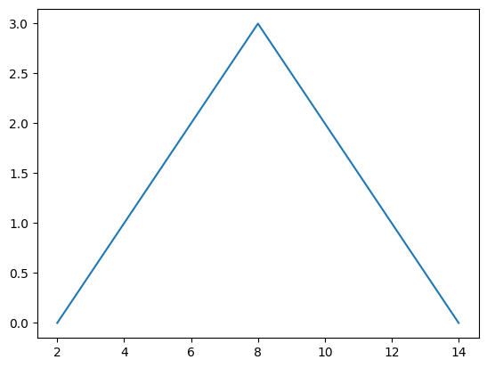

```python
fig,(ax1) = plt.subplots(1,1)

ax1.plot([2,4,6,8,10,12,14],[0,1,2,3,2,1,0])
plt.savefig("VisualizationPart02.zzz.png")
plt.show()
```

## **Description of the image shown above, VisualizationPart02.02.png**

### Type of Image

A single line plot showing a triangular waveform formed by straight line segments. The plot begins at a low x‑value, rises linearly to a peak, and then descends linearly back to the baseline.

### Overall Summary

The image illustrates how Axes.plot behaves when provided with two lists of equal length: one specifying the x‑values and the other specifying the y‑values. The resulting plot shows a piecewise linear function defined by corresponding x‑y pairs.

### Detailed Description

The figure contains one subplot displaying seven data points connected by straight lines.

- The x‑values are [2, 4, 6, 8, 10, 12, 14].
- The y‑values are [0, 1, 2, 3, 2, 1, 0].
- The curve rises from y=0 at x=2 to a peak of y=3 at x=8, then descends symmetrically back to y=0 at x=14.
- The x‑axis spans from approximately 2 to 14, and the y‑axis spans from 0 to 3.

### Purpose of the Image

The image demonstrates how Axes.plot interprets two lists as paired x‑y coordinates. It shows that when both lists are supplied, the method plots each pair as a point and connects them with straight lines, allowing precise control over the horizontal scale of the plot.

## math.cos versus numpy.cos

The standard math library and the numpy library each provide a function that returns the cosine of an angle expressed in radians. However, the input requirements of the two functions are different.

The [math.cos](https://docs.python.org/3/library/math.html#trigonometric-functions) function expects to receive a single angle in radians and returns the consine of the angle.

The numpy.cos function expects to receive a list or an array of angles expressed in radians and returns an array containing the cosine values for the corresponding angles.

The following code sample shows how each of the cos methods can be used to accomplish the same output plots.

An array named t is created containing 120 incremental values ranging from 0 to 5.95 in steps of 0.05.

The top subplot uses list comprehension and the math.cos function to create a list containing the cosine values for 120 angles based on the contents of the array named t. This list is passed as the second argument to the plot method for plotting against the values in the array named t.

The bottom subplot calls the np.cos function as the second argument to the plot method. This call is replaced by the array that is returned by the function. The contents of the array are plotted against the values in the array named t.

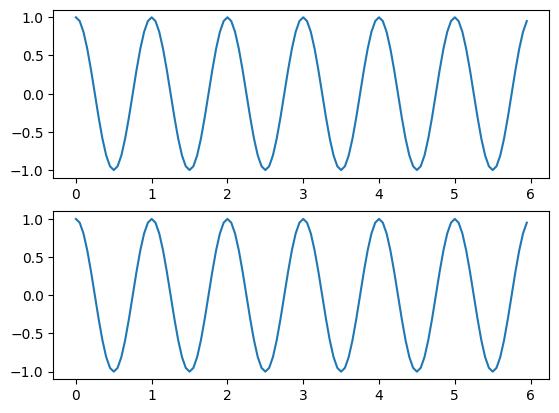

```python
fig,(ax0,ax1) = plt.subplots(2,1)
t = np.arange(0, 6.0, 0.05)

ax0.plot(t,[math.cos(2*math.pi*x) for x in t])
ax1.plot(t,np.cos(2*np.pi*t))
plt.savefig("VisualizationPart02.zzz.png")
plt.show()
```

## **Description of the image shown above, VisualizationPart02.03.png**

### Type of Image

A figure containing two stacked line plots, each showing a cosine wave over the same horizontal interval. Both plots display smooth periodic oscillations between −1 and 1.

### Overall Summary

The image compares two methods of computing cosine values in Python: one using the standard math.cos function inside a list comprehension, and the other using NumPy’s vectorized numpy.cos function. The resulting plots are visually identical, demonstrating that both approaches produce the same waveform when applied correctly.

### Detailed Description

The figure contains two subplots arranged vertically:

- **Top subplot:**
  - Plots the array `t` on the x‑axis.
  - Computes cosine values using a list comprehension that applies `math.cos(2*math.pi*x)` to each element of `t`.
  - Produces a smooth cosine wave with amplitude 1 and a frequency determined by the factor `2π`.
- **Bottom subplot:**
  - Uses the same array `t` for the x‑axis.
  - Computes cosine values using NumPy’s vectorized expression `np.cos(2*np.pi*t)`.
  - Produces a waveform identical in shape, amplitude, and frequency to the top subplot.

Both plots:

- Span an x‑range from 0 to approximately 6.
- Oscillate between −1 and 1.
- Show multiple full cycles of the cosine function.

### Purpose of the Image

The image demonstrates the difference in input expectations between math.cos and numpy.cos while showing that both can generate the same plotted output. It highlights that math.cos operates on one value at a time, requiring list comprehension, whereas numpy.cos operates on entire arrays, making it more efficient and idiomatic for numerical computing.

## A basic line plot

We will start with the basic line plot shown below and progressively enhance it.

In addition to the numpy.cos function,this code calls the numpy.exp function. This function also receives an array of input values and returns an array of corresponding output values.

Note that this code does not provide an array to control the x-axis scale. As a result, the x-axis scale is the index values from the array named t, which in this case is the set of values from 0 through 119.

Note that there are two calls to ax3.plot, resulting in two different lines being plotted in that subplot.

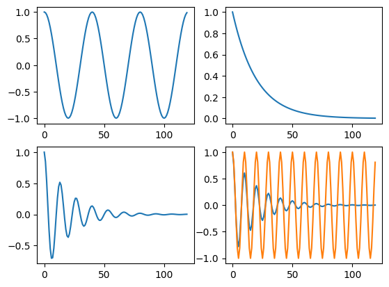

```python
fig,axes = plt.subplots(2,2)
ax0,ax1,ax2,ax3 = axes.flatten()

t = np.arange(0, 6.0, 0.05)

ax0.plot(np.cos(1*np.pi*t))
ax1.plot(np.exp(-t))
ax2.plot(np.exp(-t) * np.cos(3*np.pi*t))
ax3.plot(np.exp(-t) * np.cos(4*np.pi*t))
ax3.plot(np.cos(4*np.pi*t))
plt.savefig("VisualizationPart02.zzz.png")
plt.show()
```

## **Description of the image shown above, VisualizationPart02.04.png**

### Type of Image

A figure containing four subplots arranged in a 2×2 grid. Each subplot displays a different mathematical function plotted as a line graph, with one subplot containing two overlaid curves.

### Overall Summary

The image illustrates a basic set of line plots generated using NumPy functions such as numpy.cos and numpy.exp. Because no explicit x‑values were provided to Axes.plot, all four subplots use the index positions of the array `t` (0 through 119) as the horizontal scale. The plots demonstrate simple oscillatory, decaying, and combined behaviors.

### Detailed Description

The figure contains four subplots arranged in two rows and two columns:

- **Top‑left subplot:**
  - Plots `np.cos(1*np.pi*t)` using index values as the x‑axis.
  - Displays a sinusoidal wave oscillating between −1 and 1.
- **Top‑right subplot:**
  - Plots `np.exp(-t)`.
  - Shows a smooth exponential decay starting at 1 and approaching 0 as the index increases.
- **Bottom‑left subplot:**
  - Plots `np.exp(-t) * np.cos(3*np.pi*t)`.
  - Displays a damped oscillation whose amplitude decreases over time.
- **Bottom‑right subplot:**
  - Contains **two** plotted curves:
    - A damped oscillation: `np.exp(-t) * np.cos(4*np.pi*t)`
    - A high‑frequency cosine wave: `np.cos(4*np.pi*t)`
  - The combination shows a rapidly oscillating wave overlaid on a decaying envelope.

All subplots share the same implicit x‑axis scale (0–119), derived from the length of the array `t`.

### Purpose of the Image

The image demonstrates how basic line plots are created using Axes.plot and how NumPy functions can generate arrays of values for plotting. It also illustrates that when no explicit x‑values are provided, the plot defaults to using index positions, and that multiple calls to plot within the same Axes object produce overlaid curves.

## Clean up the x-axis scale

The following code provides the t array as the first argument to each call to the plot function, thereby causing the x-axis scale to reflect the values contained in that array. In other words, this code causes the x-axis scale to be reflective of the arguments to the functions whose outputs are being plotted instead of simply being an index to an array.

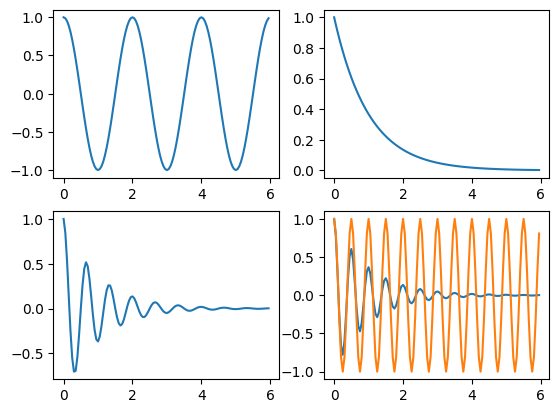

```python
fig,axes = plt.subplots(2,2)

t = np.arange(0, 6.0, 0.05)
ax0,ax1,ax2,ax3 = axes.flatten()

ax0.plot(t,np.cos(1*np.pi*t))
ax1.plot(t, np.exp(-t) )
ax2.plot(t, np.exp(-t) * np.cos(3*np.pi*t))
ax3.plot(t, np.exp(-t) * np.cos(4*np.pi*t))
ax3.plot(t, np.cos(4*np.pi*t))
plt.savefig("VisualizationPart02.zzz.png")
plt.show()
```

## **Description of the image shown above, VisualizationPart02.05.png**

### Type of Image

A figure containing four subplots arranged in a 2×2 grid. Each subplot displays a different mathematical function plotted as a line graph, with one subplot containing two overlaid curves.

### Overall Summary

The image demonstrates how providing an explicit array of x‑values to Axes.plot causes the horizontal scale to reflect those values rather than defaulting to index positions. Each subplot uses the same array `t` for the x‑axis, allowing the plotted functions to be interpreted directly in terms of their mathematical inputs.

### Detailed Description

The figure contains four subplots arranged in two rows and two columns:

- **Top‑left subplot:**
  - Plots `np.cos(1*np.pi*t)` against the array `t`.
  - Displays a cosine wave oscillating between −1 and 1 over the interval 0 to 6.
- **Top‑right subplot:**
  - Plots `np.exp(-t)` against `t`.
  - Shows a smooth exponential decay starting at 1 and approaching 0 as `t` increases.
- **Bottom‑left subplot:**
  - Plots `np.exp(-t) * np.cos(3*np.pi*t)` against `t`.
  - Displays a damped oscillation whose amplitude decreases over time.
- **Bottom‑right subplot:**
  - Contains **two** plotted curves:
    - A damped oscillation: `np.exp(-t) * np.cos(4*np.pi*t)`
    - A high‑frequency cosine wave: `np.cos(4*np.pi*t)`
  - The combination shows a rapidly oscillating wave superimposed on a decaying envelope.

All subplots share the same explicit x‑axis scale defined by the array `t`, which ranges from 0 to 6 in increments of 0.05.

### Purpose of the Image

The image illustrates how supplying an explicit x‑value array to Axes.plot changes the interpretation of the horizontal axis. It reinforces that when the x‑array is provided, the plotted functions are shown with respect to their true input values rather than implicit index positions, enabling more accurate and meaningful visualizations of mathematical functions.

## Dressing up the figure

Note that the output image shown above doesn't display the figure. However, it is possible to display the figure and to apply cosmetic properties if we choose to do so.

The call to the subplots method in the following code creates and returns a reference to a Figure object with two rows and two columns of axes. By default, the Figure object would be invisible as in the above example. However, we can pass keyword parameters to the subplots method that are in turn used to set properties on the figure. Some of the available keyword parameters are shown below.

**facecolor**: Specifies the color of the figure, which can be any allowable [color](http://matplotlib.org/2.0.2/api/colors_api.html?highlight=color#module-matplotlib.colors). There are several different ways to specify a color. For example, as illustrated below, gray shades can be given as a string encoding a float in the 0-1 range.

**linewidth**: Specifies the width in pixels of a line that forms a border around the figure. The default width is 0 causing the border to be invisible.

**edgecolor**: Specifies the color of the line that forms the border around the figure.

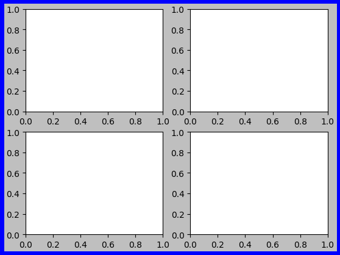

```python
fig,axes = plt.subplots(2,2,
                        facecolor='0.75',
                        linewidth=8,
                        edgecolor='Blue')
plt.savefig("VisualizationPart02.zzz.png")
plt.show()
```

## **Description of the image shown above, VisualizationPart02.06.png**

### Type of Image

A figure containing four empty subplots arranged in a 2×2 grid. Each subplot displays default axes ranging from 0.0 to 1.0 on both the horizontal and vertical scales.

### Overall Summary

The image demonstrates how cosmetic properties applied to a Figure object—specifically facecolor, linewidth, and edgecolor—affect the appearance of the entire figure. Although no data is plotted, the visual styling makes the figure itself clearly visible.

### Detailed Description

The figure contains four blank subplots arranged in two rows and two columns:

- Each subplot shows default axis tick marks from 0.0 to 1.0 on both axes.
- No plotted lines or markers appear in any subplot.
- The **figure background is a medium gray**, reflecting the `facecolor='0.75'` setting.
- A **thick blue border** surrounds the entire figure, corresponding to the specified linewidth and edgecolor.
- The individual subplot areas retain their default white plotting regions and standard axis labels.

### Purpose of the Image

The image illustrates how figure‑level cosmetic properties can be applied when creating subplots with plt.subplots. It shows that parameters such as facecolor, linewidth, and edgecolor modify the appearance of the entire figure, even when no data is plotted, helping students understand how Matplotlib handles figure‑level styling.

## Sharing axes

### If the axes not shared

If the axes are not shared, by default, the scales for each subplot are automatically adjusted to match the data being plotted as shown below. Note, for example that the vertical axes for the two subplots in the first row are different.

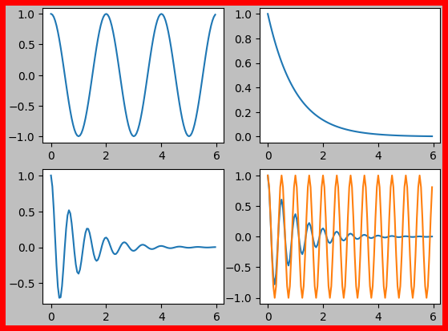

```python
fig,axes = plt.subplots(2,2,
                        facecolor='0.75',
                        linewidth=10,
                        edgecolor='Red')

t = np.arange(0, 6.0, 0.05)
ax0,ax1,ax2,ax3 = axes.flatten()

ax0.plot(t, np.cos(1*np.pi*t))
ax1.plot(t, np.exp(-t) )
ax2.plot(t, np.exp(-t) * np.cos(3*np.pi*t))
ax3.plot(t, np.exp(-t) * np.cos(4*np.pi*t))
ax3.plot(t, np.cos(4*np.pi*t))
plt.savefig("VisualizationPart02.zzz.png")
plt.show()
```

## **Description of the image shown above, VisualizationPart02.07.png**

**Type of Image**  
A four-panel figure arranged in a 2x2 grid, each panel displaying a different mathematical function. The entire figure is set against a gray background with a thick red border.

**Purpose of the Image**  
The figure illustrates differences among periodic functions, exponential decay, and damped oscillations. It helps readers compare how frequency, amplitude, and decay influence the shape of mathematical functions commonly used in physics, engineering, and signal analysis.

### If the axes are shared

The following code sets the **sharex** and **sharey** parameters for the figure to True causing the axes to be shared. This results in some obvious differences in the manner in which the subplots are dislayed. (Note that grid lines were also displayed to make the differences more obvious.)

- Tick labels now appear only on the left and on the bottom.
- Although it doesn't make any difference in this case, the tick values on the bottom are shared by the subplots in both rows.
- The tick values on the left are shared by the subplots in both columns. This causes the line plotted in the upper right to occupy only the positive portion of the subplot whereas it occupied the entire subplot when the y-axes were not shared.

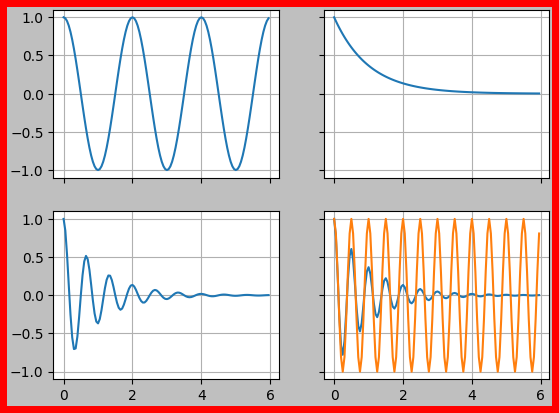

```python
fig,axes = plt.subplots(2,2,
                        facecolor='0.75',
                        linewidth=10,
                        edgecolor='Red',
                        sharex=True,
                        sharey=True)

t = np.arange(0, 6.0, 0.05)
ax0,ax1,ax2,ax3 = axes.flatten()

ax0.plot(t, np.cos(1*np.pi*t))
ax1.plot(t, np.exp(-t) )
ax2.plot(t, np.exp(-t) * np.cos(3*np.pi*t))

ax3.plot(t, np.exp(-t) * np.cos(4*np.pi*t))
ax3.plot(t, np.cos(4*np.pi*t))

ax0.grid(True)
ax1.grid(True)
ax2.grid(True)
ax3.grid(True)

plt.savefig("VisualizationPart02.zzz.png")
plt.show()
```

## **Description of the image shown above, VisualizationPart02.08.png**

**Type of Image**  
A four‑panel figure arranged in a 2x2 grid, each subplot displaying a different mathematical function. All subplots share both their x‑axis and y‑axis tick values. Grid lines are enabled in every panel, and the entire figure is framed by a gray background with a thick red border.

**Overall Summary**  
The figure demonstrates how shared axes affect the appearance of multiple subplots in a single figure. Because both the x‑axis and y‑axis are shared, tick labels appear only along the bottom and left edges of the figure. The shared y‑axis causes the upper‑right subplot to occupy only the positive portion of its vertical range, in contrast to the non‑shared version where it filled the entire subplot. The four panels display a cosine wave, an exponential decay curve, a damped oscillation, and a combined plot containing both a damped oscillation and a high‑frequency cosine wave.

**Detailed Description**

- **Top‑left panel:** A cosine function oscillating between −1 and 1 over the interval from 0 to 6. Grid lines are visible, and the y‑axis tick labels appear on the left side of this subplot.
- **Top‑right panel:** An exponential decay curve starting at 1 and approaching 0. Because the y‑axis is shared, this subplot uses the same vertical tick values as the top‑left panel, causing the curve to occupy only the positive portion of the subplot.
- **Bottom‑left panel:** A damped oscillation resembling e^(−x) * cos(3πx), with amplitude decreasing as x increases. The shared x‑axis places the tick labels along the bottom row only, and the shared y‑axis aligns its vertical scale with the panels above.
- **Bottom‑right panel:** Two functions plotted together: a damped oscillation and a high‑frequency cosine wave. Both curves share the same axis limits as the other subplots, and grid lines are displayed to emphasize the alignment of tick values across the figure.
- **Overall styling:** All four subplots share identical x‑axis and y‑axis tick values. Tick labels appear only on the left and bottom edges of the figure. Grid lines are enabled in every panel to highlight the alignment created by shared axes.

**Purpose of the Image**  
The figure illustrates how enabling shared axes affects the layout and interpretation of multiple subplots. It highlights the reduction of redundant tick labels, the alignment of tick values across rows and columns, and the visual consequences of forcing all subplots to use the same vertical scale. The vertical tick values differ from one subplot to the next in the non‑shared version, but here they are identical because the axes are shared.

**More on Sharing**

According to MS Copilot, when subplots share an axis in matplotlib, they also share the numerical scale for that axis. Sharing the y-axis means that all subplots use the same vertical limits and tick values, even if their data would normally require different ranges. Sharing the x-axis works the same way but applies to the horizontal scale. This can change the appearance of individual plots because none of the shared subplots are allowed to choose their own axis limits independently.

## Legends, subplot titles, and tight_layout

The following code places a legend in the bottom-right subplot. There are several ways to create legends. This code creates a label for each of the lines being plotted. Then it calls the legend method that causes those labels to be turned into a legend and placed on the subplot.

The location of the legend can be specified with a keyword parameter in the call to the legend method. In this case, the legend was specified to be located in the 'upper right'.

There are many other keyword parameters, such as framealpha and facecolor, that can be passed to the legend method to control the appearance of the legend. This code sets those two values to cause the background of the box containing the legend text to be partially transparent green -- not pretty, just for illustration.

Then the code calls the set_title method to place a title above the lower-right subplot. There are several keyword parameters that can be passed to control the appearance of the title. This code simply accepts the default of a centered title in the default font.

Once we start decorating the figure with titles, etc., we need to call [tight_layout](http://matplotlib.org/2.0.2/users/tight_layout_guide.html) to automatically adjust subplot parameters so that the subplots and the decorations fit properly without overlap in the figure area.

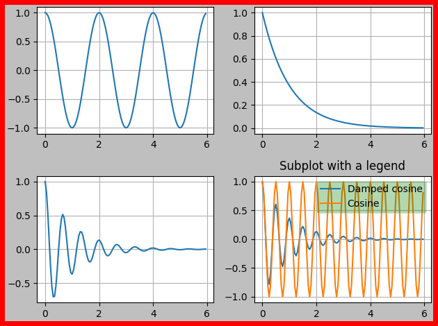

```python
fig,axes = plt.subplots(2,2,
                        facecolor='0.75',
                        linewidth=10,
                        edgecolor='Red')

t = np.arange(0, 6.0, 0.05)
ax0,ax1,ax2,ax3 = axes.flatten()

ax0.plot(t, np.cos(1*np.pi*t))
ax1.plot(t, np.exp(-t) )
ax2.plot(t, np.exp(-t) * np.cos(3*np.pi*t))

ax3.plot(t, np.exp(-t) * np.cos(4*np.pi*t),label='Damped cosine')
ax3.plot(t, np.cos(4*np.pi*t),label='Cosine')
ax3.legend(loc='upper right',framealpha=0.3,facecolor='Green')
ax3.set_title('Subplot with a legend')

ax0.grid(True)
ax1.grid(True)
ax2.grid(True)
ax3.grid(True)

fig.tight_layout()
plt.savefig("VisualizationPart02.zzz.png")
plt.show()
```

## **Description of the image shown above, VisualizationPart02.09.png**

**Type of Image**  
A four‑panel figure arranged in a 2x2 grid, each subplot displaying a different mathematical function. The lower‑right subplot includes a legend and a subplot title. Grid lines are enabled in all panels, and the entire figure is framed by a gray background with a thick red border.

**Overall Summary**  
The figure demonstrates how to add legends, apply subplot titles, and use tight_layout to prevent overlapping elements. The lower‑right subplot contains two plotted functions with labels that are converted into a legend positioned in the upper‑right corner. The legend box has a partially transparent green background to illustrate customization options. A title is placed above the lower‑right subplot, and tight_layout is used to ensure that the title, legend, and subplots fit cleanly within the figure.

**Detailed Description**

- **Top‑left panel:** A cosine wave oscillating between −1 and 1 over the interval from 0 to 6. Grid lines are displayed.
- **Top‑right panel:** An exponential decay curve starting at 1 and approaching 0 as the horizontal variable increases. Grid lines are displayed.
- **Bottom‑left panel:** A damped oscillation resembling e^(−x) * cos(3πx), with amplitude decreasing over time. Grid lines are displayed.
- **Bottom‑right panel:** Two functions plotted together: a damped cosine wave and a high‑frequency cosine wave. Each line is given a label, and the legend method converts those labels into a legend placed in the upper‑right corner. The legend box uses a partially transparent green background (framealpha=0.3, facecolor='Green') to illustrate customization. A title reading “Subplot with a legend” appears above this panel. Grid lines are displayed.
- **Overall styling:** All four subplots share consistent axis formatting and grid lines. The figure uses a gray background and a thick red border. The call to tight_layout adjusts spacing so that the title and legend do not overlap the subplots.

**Purpose of the Image**  
The figure illustrates how to add legends and titles to individual subplots and how to customize the appearance of legend boxes. It also demonstrates the importance of calling tight_layout when decorative elements such as titles and legends are added, ensuring that all components fit properly within the figure area.

## X and Y labels

The following code creates and displays labels for the X and Y axes for each of the subplots. Note that without the call to the tight_layout method, this might create an overlapping mess.

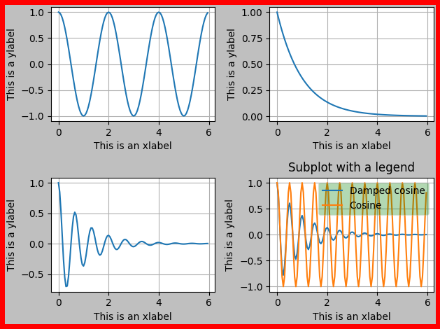

```python
fig,axes = plt.subplots(2,2,
                        facecolor='0.75',
                        linewidth=10,
                        edgecolor='Red')

t = np.arange(0, 6.0, 0.05)
ax0,ax1,ax2,ax3 = axes.flatten()

ax0.plot(t, np.cos(1*np.pi*t))
ax0.set_ylabel('This is a ylabel')
ax0.set_xlabel('This is an xlabel')

ax1.plot(t, np.exp(-t) )
ax1.set_ylabel('This is a ylabel')
ax1.set_xlabel('This is an xlabel')

ax2.plot(t, np.exp(-t) * np.cos(3*np.pi*t))
ax2.set_ylabel('This is a ylabel')
ax2.set_xlabel('This is an xlabel')

ax3.plot(t, np.exp(-t) * np.cos(4*np.pi*t),label='Damped cosine')
ax3.plot(t, np.cos(4*np.pi*t),label='Cosine')
ax3.legend(loc='upper right',framealpha=0.3,facecolor='Green')
ax3.set_title('Subplot with a legend')
ax3.set_ylabel('This is a ylabel')
ax3.set_xlabel('This is an xlabel')

ax0.grid(True)
ax1.grid(True)
ax2.grid(True)
ax3.grid(True)

fig.tight_layout()
plt.savefig("VisualizationPart02.zzz.png")
plt.show()
```

## **Description of the image shown above, VisualizationPart02.10.png**

**Type of Image**  
A four‑panel figure arranged in a 2x2 grid, each subplot displaying a different mathematical function. Every subplot includes both an x‑axis label and a y‑axis label. Grid lines are enabled throughout, and the entire figure is framed by a gray background with a thick red border.

**Overall Summary**  
The figure demonstrates how to apply x‑axis and y‑axis labels to individual subplots within a multi‑panel layout. Each subplot displays a different function, and all four include the same text labels: “This is an xlabel” and “This is a ylabel.” A legend and subplot title appear in the lower‑right panel. The call to `tight_layout` ensures that the axis labels, title, and legend fit cleanly without overlapping adjacent subplots.

**Detailed Description**

- **Top‑left panel:** A cosine wave oscillating between −1 and 1 over the interval from 0 to 6. The subplot includes the labels “This is a ylabel” on the vertical axis and “This is an xlabel” on the horizontal axis. Grid lines are displayed.
- **Top‑right panel:** An exponential decay curve starting at 1 and approaching 0 as x increases. The same x‑ and y‑axis labels appear, and grid lines are enabled.
- **Bottom‑left panel:** A damped oscillation resembling e^(−x) * cos(3πx), with amplitude decreasing over time. The subplot includes the same axis labels and grid lines.
- **Bottom‑right panel:** Two functions plotted together: a damped cosine wave and a cosine wave of constant amplitude. A legend in the upper‑right corner identifies the two curves, and a title reading “Subplot with a legend” appears above the panel. The subplot also includes the same x‑ and y‑axis labels and grid lines.
- **Overall styling:** All four subplots use identical axis label text, consistent grid formatting, and the same figure‑level background and border styling. The call to `tight_layout` adjusts spacing so that labels, title, and legend do not overlap.

**Purpose of the Image**  
The figure illustrates how to add axis labels to each subplot in a multi‑panel figure and demonstrates the importance of using `tight_layout` to prevent overlapping elements. It shows how labels, titles, and legends interact within a grid of subplots and how consistent labeling supports readability across multiple panels.

## Subplot and figure titles

The following code adds a title to each of the subplots and then adds a title to the figure. Note the use of the following code to add the title to the figure: fig.suptitle('A figure title')

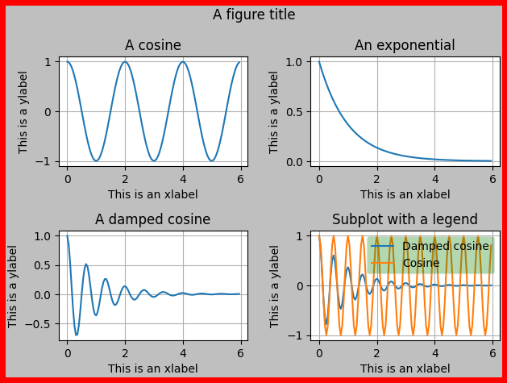

```python
fig,axes = plt.subplots(2,2,
                        facecolor='0.75',
                        linewidth=10,
                        edgecolor='Red')

t = np.arange(0, 6.0, 0.05)
ax0,ax1,ax2,ax3 = axes.flatten()

ax0.plot(t, np.cos(1*np.pi*t))
ax0.set_ylabel('This is a ylabel')
ax0.set_xlabel('This is an xlabel')
ax0.set_title('A cosine')

ax1.plot(t, np.exp(-t) )
ax1.set_ylabel('This is a ylabel')
ax1.set_xlabel('This is an xlabel')
ax1.set_title('An exponential')

ax2.plot(t, np.exp(-t) * np.cos(3*np.pi*t))
ax2.set_ylabel('This is a ylabel')
ax2.set_xlabel('This is an xlabel')
ax2.set_title('A damped cosine')

ax3.plot(t, np.exp(-t) * np.cos(4*np.pi*t),label='Damped cosine')
ax3.plot(t, np.cos(4*np.pi*t),label='Cosine')
ax3.legend(loc='upper right',framealpha=0.3,facecolor='Green')
ax3.set_title('Subplot with a legend')
ax3.set_ylabel('This is a ylabel')
ax3.set_xlabel('This is an xlabel')

ax0.grid(True)
ax1.grid(True)
ax2.grid(True)
ax3.grid(True)

fig.suptitle('A figure title')
fig.tight_layout()
plt.savefig("VisualizationPart02.zzz.png")
plt.show()
```

## **Description of the image shown above, VisualizationPart02.11.png**

**Type of Image**  
A four‑panel figure arranged in a 2x2 grid, each subplot displaying a different mathematical function. Every subplot includes a title, and the entire figure has a centered figure‑level title positioned above all subplot titles. Grid lines are enabled throughout, and the figure uses a gray background with a thick red border.

**Overall Summary**  
The figure demonstrates how to add titles to individual subplots and how to place a title at the figure level. Each subplot displays a different function and includes both x‑axis and y‑axis labels. The lower‑right subplot also contains a legend.

**Detailed Description**

- **Top‑left panel:** Titled “A cosine,” this subplot shows a cosine wave oscillating between −1 and 1 over the interval from 0 to 6. The axes are labeled “This is a ylabel” and “This is an xlabel,” and grid lines are displayed.
- **Top‑right panel:** Titled “An exponential,” this subplot displays an exponential decay curve starting at 1 and approaching 0 as x increases. The same axis labels and grid formatting are used.
- **Bottom‑left panel:** Titled “A damped cosine,” this subplot shows a cosine wave whose amplitude decreases over time. It includes the same axis labels and grid lines as the other panels.
- **Bottom‑right panel:** Titled “Subplot with a legend,” this subplot contains two functions: a damped cosine wave and a regular cosine wave. A legend in the upper‑right corner identifies the two curves, and the subplot includes the same axis labels and grid lines as the others.
- **Figure‑level title:** A centered title reading “A figure title” appears above all four subplots.

**Purpose of the Image**  
The figure illustrates how to apply titles to individual subplots and how to add a figure‑level title that sits above them. It demonstrates the importance of adjusting layout spacing when combining subplot titles, axis labels, legends, and a figure title, ensuring that all elements remain readable and well‑positioned.

## Modifying the x-axis scale with xlim

Once you have established a relationship between the x-axis scale and the values being plotted, you can call the Axes.set_xlim method to control the visible range of the x-axis scale.

The following code specifies that only that portion of the curve that lies between 0 and 1.0 in the lower-left subplot should be visible in the available space. This has the impact of causing that portion of the curve to the right of 1.0 to be out of the visible range for the plot.

The code also sets the visible range for the lower-right subplot to be from -2 to 8. This results in a blank area on both ends of the curve because the curve is specified only for the interval from 0 to 6.

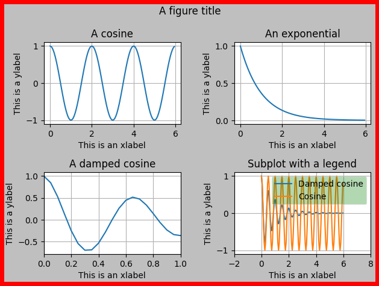

```python
fig,axes = plt.subplots(2,2,
                        facecolor='0.75',
                        linewidth=10,
                        edgecolor='Red')

t = np.arange(0, 6.0, 0.05)
ax0,ax1,ax2,ax3 = axes.flatten()

ax0.plot(t, np.cos(1*np.pi*t))
ax0.set_ylabel('This is a ylabel')
ax0.set_xlabel('This is an xlabel')
ax0.set_title('A cosine')

ax1.plot(t, np.exp(-t) )
ax1.set_ylabel('This is a ylabel')
ax1.set_xlabel('This is an xlabel')
ax1.set_title('An exponential')

ax2.plot(t, np.exp(-t) * np.cos(3*np.pi*t))
ax2.set_ylabel('This is a ylabel')
ax2.set_xlabel('This is an xlabel')
ax2.set_title('A damped cosine')

ax2.set_xlim(0,1)

ax3.plot(t, np.exp(-t) * np.cos(4*np.pi*t),label='Damped cosine')
ax3.plot(t, np.cos(4*np.pi*t),label='Cosine')
ax3.legend(loc='upper right',framealpha=0.3,facecolor='Green')
ax3.set_title('Subplot with a legend')
ax3.set_ylabel('This is a ylabel')
ax3.set_xlabel('This is an xlabel')

ax3.set_xlim(-2,8)

ax0.grid(True)
ax1.grid(True)
ax2.grid(True)
ax3.grid(True)

fig.suptitle('A figure title')
fig.tight_layout()
plt.savefig("VisualizationPart02.zzz.png")
plt.show()
```

## **Description of the image shown above, VisualizationPart02.12.png**

**Type of Image**  
A four‑panel figure arranged in a 2x2 grid, each subplot displaying a different mathematical function. All subplots include titles, axis labels, and grid lines. The lower‑left and lower‑right subplots use modified x‑axis limits to demonstrate how `set_xlim` affects the visible portion of a plot. The entire figure has a gray background, a thick red border, and a centered figure‑level title at the top.

**Overall Summary**  
The figure illustrates how adjusting x‑axis limits changes what portion of a function is visible within a subplot. The lower‑left subplot restricts the x‑axis to the interval from 0 to 1, showing only the initial segment of a damped cosine wave. The lower‑right subplot expands the x‑axis range to −2 through 8, creating blank space on both sides because the plotted data exists only between 0 and 6. All subplots include descriptive titles, axis labels, and grid lines, and the figure includes a centered title above the grid.

**Detailed Description**

- **Top‑left panel:** Titled “A cosine,” this subplot shows a cosine wave oscillating between −1 and 1 over the interval from 0 to 6. It includes the labels “This is a ylabel” and “This is an xlabel,” and grid lines are displayed.
- **Top‑right panel:** Titled “An exponential,” this subplot displays an exponential decay curve starting at 1 and approaching 0 as x increases. It uses the same axis labels and grid formatting as the other panels.
- **Bottom‑left panel:** Titled “A damped cosine,” this subplot shows a cosine wave with decreasing amplitude. The x‑axis limits are set to 0 through 1, so only the initial portion of the function is visible. The remainder of the curve lies outside the visible range. Axis labels and grid lines are included.
- **Bottom‑right panel:** Titled “Subplot with a legend,” this subplot contains two curves: a damped cosine wave and a regular cosine wave. A legend in the upper‑right corner identifies the two lines. The x‑axis limits are set to −2 through 8, extending the visible range beyond the domain of the data and producing blank areas on both sides of the plotted curves. Axis labels and grid lines are included.
- **Figure‑level title:** A centered title reading “A figure title” appears above all four subplots, providing a descriptive heading for the entire figure.

**Purpose of the Image**  
The figure demonstrates how the `set_xlim` method can be used to zoom in on a specific portion of a function or expand the visible range beyond the data domain. It highlights how axis limits interact with subplot titles, legends, and figure‑level titles within a multi‑panel layout, reinforcing the importance of axis control in data visualization.

## Modifying the y-axis scale with ylim

Normally the y-axis scale is set automatically to fit the values of the data being plotted. However, you can call the Axes.set_ylim method to control the visible range of the y-axis scale.

The following code specifies that only that portion of the curve having values that lie between -0.2 and +0.2 in the two bottom subplots should be visible in the available space. This has the impact of causing that portion of the curves below -0.2 and above 0.2 to be out of the visible range for the plots.

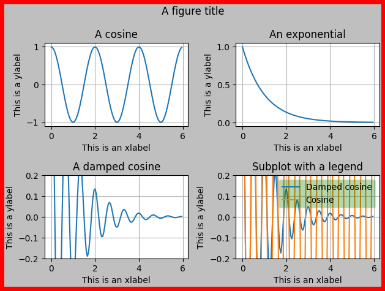

```python
fig,axes = plt.subplots(2,2,
                        facecolor='0.75',
                        linewidth=10,
                        edgecolor='Red')

t = np.arange(0, 6.0, 0.05)
ax0,ax1,ax2,ax3 = axes.flatten()

ax0.plot(t, np.cos(1*np.pi*t))
ax0.set_ylabel('This is a ylabel')
ax0.set_xlabel('This is an xlabel')
ax0.set_title('A cosine')

ax1.plot(t, np.exp(-t) )
ax1.set_ylabel('This is a ylabel')
ax1.set_xlabel('This is an xlabel')
ax1.set_title('An exponential')

ax2.plot(t, np.exp(-t) * np.cos(3*np.pi*t))
ax2.set_ylabel('This is a ylabel')
ax2.set_xlabel('This is an xlabel')
ax2.set_title('A damped cosine')

ax2.set_ylim(-0.2,0.2)

ax3.plot(t, np.exp(-t) * np.cos(4*np.pi*t),label='Damped cosine')
ax3.plot(t, np.cos(4*np.pi*t),label='Cosine')
ax3.legend(loc='upper right',framealpha=0.3,facecolor='Green')
ax3.set_title('Subplot with a legend')
ax3.set_ylabel('This is a ylabel')
ax3.set_xlabel('This is an xlabel')

ax3.set_ylim(-0.2,0.2)

ax0.grid(True)
ax1.grid(True)
ax2.grid(True)
ax3.grid(True)

fig.suptitle('A figure title')
fig.tight_layout()
plt.savefig("VisualizationPart02.zzz.png")
plt.show()
```

## **Description of the image shown above, VisualizationPart02.13.png**

**Type of Image**  
A four‑panel figure arranged in a 2x2 grid, each subplot displaying a different mathematical function. All subplots include titles, axis labels, and grid lines. The two bottom subplots use modified y‑axis limits to demonstrate how `set_ylim` affects the visible portion of a plot. The entire figure has a gray background, a thick red border, and a centered figure‑level title at the top.

**Overall Summary**  
The figure illustrates how adjusting the y‑axis limits changes what portion of a function is visible within a subplot. The bottom two subplots restrict the y‑axis to the interval from −0.2 to +0.2, showing only the small‑amplitude region near the horizontal axis. Portions of the curves that fall outside this narrow range are not displayed. The top two subplots retain their full automatic y‑axis scaling. All subplots include descriptive titles, axis labels, and grid lines, and the figure includes a centered title above the grid.

**Detailed Description**

- **Top‑left panel:** Titled “A cosine,” this subplot shows a cosine wave oscillating between −1 and 1 over the interval from 0 to 6. It includes the labels “This is a ylabel” and “This is an xlabel,” and grid lines are displayed.
- **Top‑right panel:** Titled “An exponential,” this subplot displays an exponential decay curve starting at 1 and approaching 0 as x increases. It uses the same axis labels and grid formatting as the other panels.
- **Bottom‑left panel:** Titled “A damped cosine,” this subplot shows a cosine wave with decreasing amplitude. The y‑axis limits are set to −0.2 through +0.2, so only the small‑amplitude portion of the curve near the horizontal axis is visible. The rest of the function lies outside the visible range. Axis labels and grid lines are included.
- **Bottom‑right panel:** Titled “Subplot with a legend,” this subplot contains two curves: a damped cosine wave and a regular cosine wave. A legend in the upper‑right corner identifies the two lines. The y‑axis limits are set to −0.2 through +0.2, restricting the visible portion of both curves to the region near the horizontal axis. Axis labels and grid lines are included.
- **Figure‑level title:** A centered title reading “A figure title” appears above all four subplots, providing a descriptive heading for the entire figure.

**Purpose of the Image**  
The figure demonstrates how the `set_ylim` method can be used to zoom in on a narrow vertical range of interest. By restricting the y‑axis to a small interval, the bottom subplots highlight only the portion of each function that lies near zero, while hiding the larger‑amplitude regions. This example reinforces how axis limits interact with subplot titles, legends, and figure‑level titles within a multi‑panel layout.

## Modifying the axes with xscale and yscale

Normally the x-axis and y-axis scales are linear. However, you can call the Axes.set_xscale and Axes.set_yscale methods to cause the data to be plotted on nonlinear scales, such as a log scale.

The following code causes the upper-right subplot to be plotted on a log vertical scale. This is equivalent to manually plotting the curve on semi-log graph paper if you know what that means.

This has the impact of causing the exponenial curve to appear as a straight line on the plot.

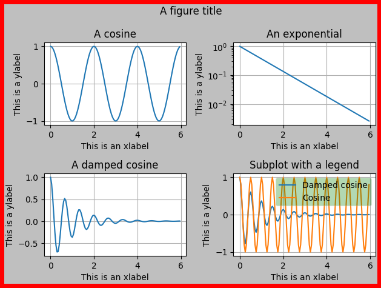

```python
fig,axes = plt.subplots(2,2,
                        facecolor='0.75',
                        linewidth=10,
                        edgecolor='Red')

t = np.arange(0, 6.0, 0.05)
ax0,ax1,ax2,ax3 = axes.flatten()

ax0.plot(t, np.cos(1*np.pi*t))
ax0.set_ylabel('This is a ylabel')
ax0.set_xlabel('This is an xlabel')
ax0.set_title('A cosine')

ax1.plot(t, np.exp(-t) )
ax1.set_ylabel('This is a ylabel')
ax1.set_xlabel('This is an xlabel')
ax1.set_title('An exponential')

ax1.set_yscale('log')

ax2.plot(t, np.exp(-t) * np.cos(3*np.pi*t))
ax2.set_ylabel('This is a ylabel')
ax2.set_xlabel('This is an xlabel')
ax2.set_title('A damped cosine')

ax3.plot(t, np.exp(-t) * np.cos(4*np.pi*t),label='Damped cosine')
ax3.plot(t, np.cos(4*np.pi*t),label='Cosine')
ax3.legend(loc='upper right',framealpha=0.3,facecolor='Green')
ax3.set_title('Subplot with a legend')
ax3.set_ylabel('This is a ylabel')
ax3.set_xlabel('This is an xlabel')

ax0.grid(True)
ax1.grid(True)
ax2.grid(True)
ax3.grid(True)

fig.suptitle('A figure title')
fig.tight_layout()
plt.savefig("VisualizationPart02.zzz.png")
plt.show()
```

## **Description of the image shown above, VisualizationPart02.14.png**

**Type of Image**  
A four‑panel figure arranged in a 2x2 grid, each subplot displaying a different mathematical function. All subplots include titles, axis labels, and grid lines. The upper‑right subplot uses a logarithmic y‑axis scale to demonstrate how `set_yscale('log')` affects the appearance of an exponential curve. The entire figure has a gray background, a thick red border, and a centered figure‑level title at the top.

**Overall Summary**  
The figure illustrates how modifying axis scales with `set_xscale` and `set_yscale` can change the way data is displayed. In this example, the upper‑right subplot is plotted on a logarithmic vertical scale, causing the exponential decay curve to appear as a straight line. The other three subplots use standard linear scales. All subplots include descriptive titles, axis labels, and grid lines, and the figure includes a centered title above the grid.

**Detailed Description**

- **Top‑left panel:** Titled “A cosine,” this subplot shows a cosine wave oscillating between −1 and 1 over the interval from 0 to 6. It includes the labels “This is a ylabel” and “This is an xlabel,” and grid lines are displayed.
- **Top‑right panel:** Titled “An exponential,” this subplot displays an exponential decay curve. The y‑axis is plotted on a logarithmic scale, causing the curve to appear as a straight descending line. The subplot includes the same axis labels and grid formatting as the others.
- **Bottom‑left panel:** Titled “A damped cosine,” this subplot shows a cosine wave with decreasing amplitude over time. It uses a standard linear scale for both axes and includes axis labels and grid lines.
- **Bottom‑right panel:** Titled “Subplot with a legend,” this subplot contains two curves: a damped cosine wave and a regular cosine wave. A legend in the upper‑right corner identifies the two lines. Both axes use linear scales, and the subplot includes axis labels and grid lines.
- **Figure‑level title:** A centered title reading “A figure title” appears above all four subplots, providing a descriptive heading for the entire figure.

**Purpose of the Image**  
The figure demonstrates how nonlinear axis scaling—specifically a logarithmic y‑axis—affects the visual representation of data. By plotting the exponential decay on a log scale, the curve becomes a straight line, illustrating the relationship between exponential functions and logarithmic transformations. This example reinforces how axis scaling interacts with subplot titles, legends, and figure‑level titles within a multi‑panel layout.

## Spines and text

According to the documentation [matplotlib.spines](https://matplotlib.org/api/spines_api.html) are the lines connecting the axis tick marks and noting the boundaries of the data area. Stated differently, they are the four lines that outline a rectangular panel. They can be placed at arbitrary positions. They can also be made invisible by setting their color to none.

The following code uses the spines to form axes that intersect at the origin of each plot. The code also uses LaTeX to place labels inside of each plot describing the curve, and finally the code places some text at the lower-left of the figure.

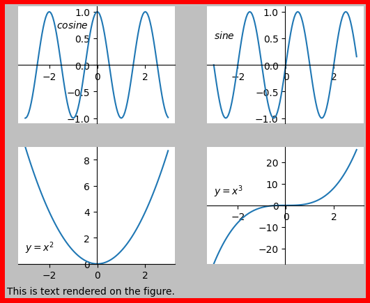

```python
fig,axes = plt.subplots(2,2,
                        facecolor='0.75',
                        linewidth=10,
                        edgecolor='Red')

t = np.arange(-3.0, 3.0, 0.05)
ax0,ax1,ax2,ax3 = axes.flatten()

ax0.spines['left'].set_position('center')
ax0.spines['right'].set_color('none')
ax0.spines['bottom'].set_position('center')
ax0.spines['top'].set_color('none')
ax0.text(-1.7,0.7,'$cosine$')
ax0.plot(t,np.cos(1*np.pi*t))

ax1.spines['left'].set_position('center')
ax1.spines['right'].set_color('none')
ax1.spines['bottom'].set_position('center')
ax1.spines['top'].set_color('none')
ax1.text(-3,0.5,'$sine$')
ax1.plot(t,np.sin(1*np.pi*t))

ax2.spines['left'].set_position('center')
ax2.spines['right'].set_color('none')
ax2.spines['top'].set_color('none')
ax2.set_ylim(0,9)
ax2.text(-3,1.0,'$y=x^2$')
ax2.plot(t, [x**2 for x in t])


ax3.spines['left'].set_position('center')
ax3.spines['right'].set_color('none')
ax3.spines['bottom'].set_position('center')
ax3.spines['top'].set_color('none')
ax3.set_ylim(-27,27)
ax3.text(-3,5,'$y=x^3$')
ax3.plot(t, [x**3 for x in t])

plt.figtext(0.1,0.02,'This is text rendered on the figure.')
plt.savefig("VisualizationPart02.zzz.png")
plt.show()
```

## **Description of the image shown above, VisualizationPart02.15.png**

**Type of Image**  
A four‑panel figure arranged in a 2x2 grid, each subplot displaying a different mathematical function. All subplots use customized spine positions so that the horizontal and vertical axes intersect at the origin. Each subplot contains LaTeX‑rendered text labeling the function being plotted. Additional text is placed near the lower‑left corner of the overall figure. The figure uses a gray background and a thick red border.

**Overall Summary**  
The figure demonstrates how to manipulate spines to reposition axes so that they cross at the origin, how to hide unused spines, and how to place LaTeX‑formatted labels directly inside each subplot. Each subplot displays a different function—cosine, sine, a quadratic, and a cubic—plotted over the interval from −3 to 3. The top and right spines are removed, and the left and bottom spines are moved to the center. A line of text is added at the figure level using `plt.figtext`.

**Detailed Description**

- **Top‑left panel:** Shows the cosine function over the interval from −3 to 3. The left and bottom spines intersect at the origin, while the top and right spines are hidden. A LaTeX label reading “cosine” appears inside the plot near the upper‑left region.
- **Top‑right panel:** Displays the sine function with the same centered‑axis configuration. A LaTeX label reading “sine” appears inside the plot near the upper‑left region.
- **Bottom‑left panel:** Shows the quadratic function \(y = x^2\). The top and right spines are hidden, and the left spine is centered. The y‑axis range is restricted to 0 through 9. A LaTeX label reading “\(y = x^2\)” appears inside the plot.
- **Bottom‑right panel:** Displays the cubic function \(y = x^3\). The left and bottom spines intersect at the origin, and the y‑axis range is set from −27 to 27. A LaTeX label reading “\(y = x^3\)” appears inside the plot. The top and right spines are hidden.
- **Figure‑level text:** A line of text reading “This is text rendered on the figure.” appears near the lower‑left corner of the overall figure, placed using `plt.figtext`.

**Purpose of the Image**  
The figure illustrates how to reposition and hide spines to create centered axes, how to annotate plots with LaTeX‑formatted text, and how to place text at the figure level. It demonstrates how these techniques can be combined to produce clean, mathematically styled visualizations that emphasize the structure and symmetry of the functions being plotted.

#### --To be continued in the tutorial titled Visualization Exercises Part 3--

Author: Prof. Richard G. Baldwin, Austin Community College, Austin, TX

File: VisualizationPart02.ipynb

Revised: 03/12/26

Copyright 2018 Richard G. Baldwin

-end-